# Lineup Experimentation Design

Emily Robinson

### Line-up Task

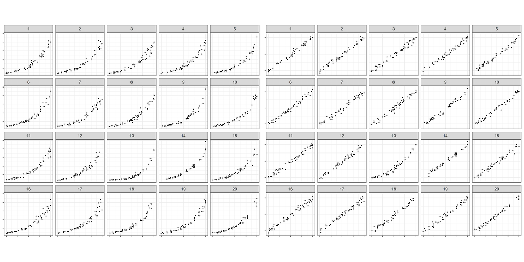

### Treatment Design

2 test_params x (18 test param_value levels + 6 rorschach param_values levels)

1. Test_param (2 levels)
   - Log Scale
   - Linear Scale
2. Param_value (18 test levels + 6 rorschach levels) This is made up of a combination of curvature (Hard / Medium / Easy), variability (Low / High), and panel (Target / Null)
   - Within low / high variability (2 variabilities x 6 combinations of the 3 curvature difficulties = 12 test treatments)
     - Hard Target / Easy Null
     - Hard Target / Medium Null
     - Medium Target / Easy Null
     - Medium Target / Medium Null
     - Easy Target / Medium Null
     - Easy Target / Hard Null
   - Within hard / medium / easy curvature (3 curvatures x 2 combinations of the 2 varaibilities = 6 test treatments)
     - Low Target / High Null
     - High Target / Low Null
   - For the rorschach treatments (6 levels of curvature x variability where the target and null are the same param_value)
     - Hard Low
     - Hard High
     - Medium Low
     - Medium High
     - Easy Low
     - Easy High
   - param_value labels are given by: target-*Curvature*-*Variability*_null-*Curvature*-*Variability*_*rorschach*
     - Example: target-E-Lv_null-H-Lv_r0 indicates the target panel gets the easy curvature and low variability parameters while the null panels gets the hard curvature and low variability parameters and this is not a rorschach plot (r0).
     - Example: target-E-Lv_null-E-Lv_r1 indicates the lineup is a rorschach (r1) with easy curvature and low varaibility parameters for both the target and null panels.
- 2 reps (datasets) were created for each param_value (total of 2 x (18 + 6) = 48 datasets)
- Each dataset was used in a linear scale lineup and a log scale lineup (total of 2 x 48 = 96 lineups)

### Experiment Design

Incomplete Block Design with a Split Plot

- Each individual recieved a total of 20 plots (18 test plots and 2 rorschach plots)
- Of the 18 test plots
  - 9 of the 18 test param_values were randomly selected for each individual (i.e. IBD with block size of 9, 18 treatment levels, and “unlimmited” blocks)
  - Each of the 9 selected param_values x test_param (log/linear) were then randomly assigned a dataset rep. (i.e. each of the 9 param values was given on both the linear/log scale but the dataset (rep) may have differed between the linear/log scale).
- Similarly, of the 2 rorschach plots
  - 1 of the 6 rorschach param_values was randomly selected for each individual and each test_param (log/linear scale) was randomly assigned a dataset (rep).

Therefore,

- Individual = block
- Param_value = whole plot factor
- Test_param = split plot factor
- Rep (*currently ignoring this, but would this be a row-column blocking type of design?*)

### Preliminary Analysis

For the $i^{th}$ param_value on the $j^{th}$ scale answered by the $k^{th}$ participant, $y_{ijk} = 1$ if the participant is correct and $y_{ijk} = 0$ if the participant is not correct.

Then $y_{ijk} | b_k wp_j ~ Bin(1,p_{ijk})$ where $\eta_{ijk} = \ln\left(\frac{p_{ijk}}{1-p_{ijk}}\right) = \eta + \tau_i + \delta_j + \tau\delta_{ij} + b_k + wp_{ik}$ with $\tau_i$ denoting the effect of the parameter value and $\delta_j$ denoting the effect of the test parameter.

*Assuming n participants per t param_values & not accounting for dataset (rep)*

| Source of Variation | DF |
| --- | --- |
| participant - *Block Variance* | n-1 |
| param_value | t-1 |
| participant x param_value - *WP Variance* | (n-1)(t-1) |
| test_param | (2-1) = 1 |
| param_value x test_param | (t-1)(2-1) = (t-1) |
| test_param x participant (param_value) - *overdispersion?* | (2-1)(n-1)(t) |

### Raw Values

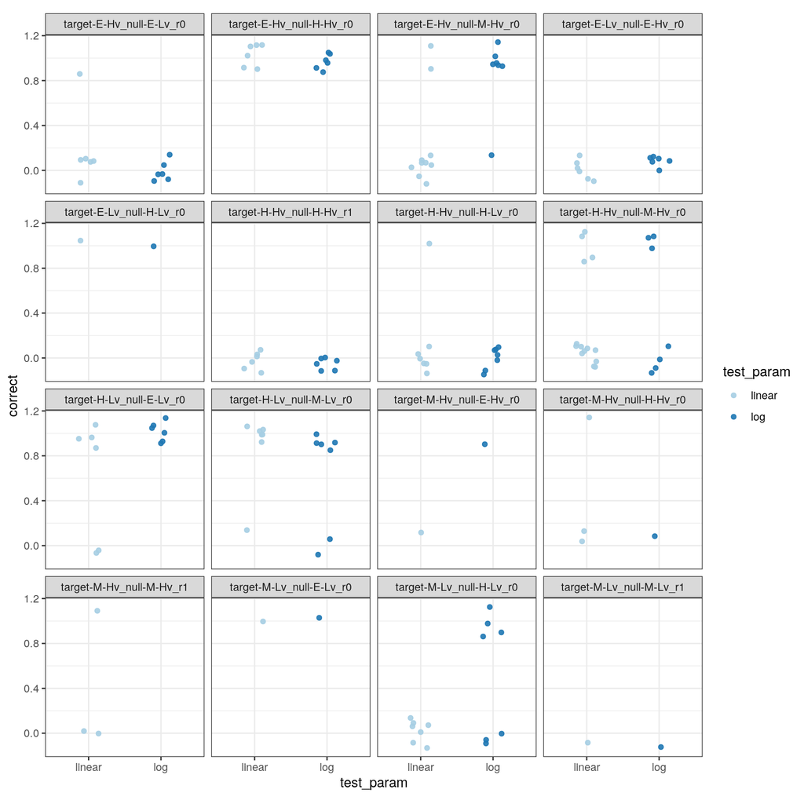

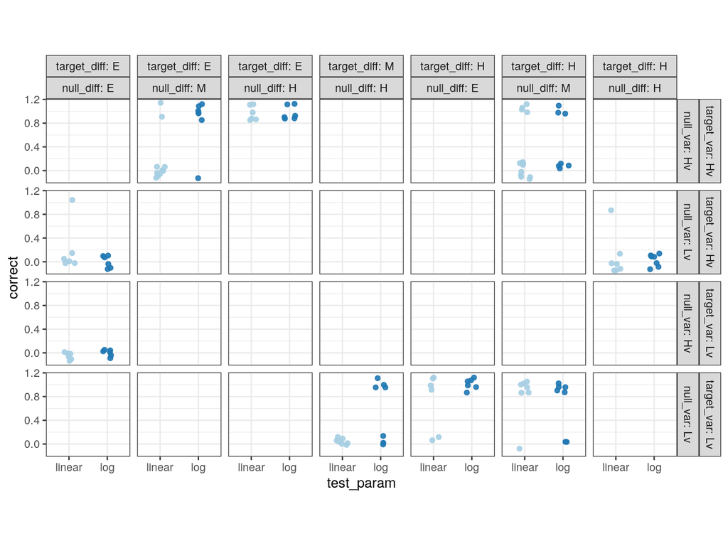

#### Parameter Value Summary

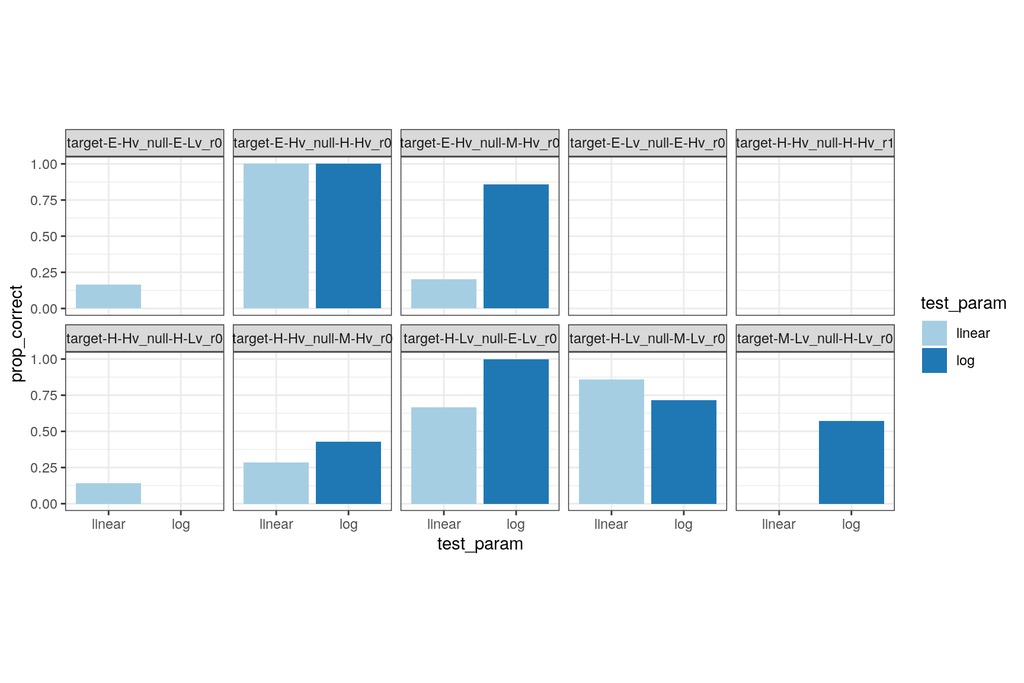

#### Participant Summary

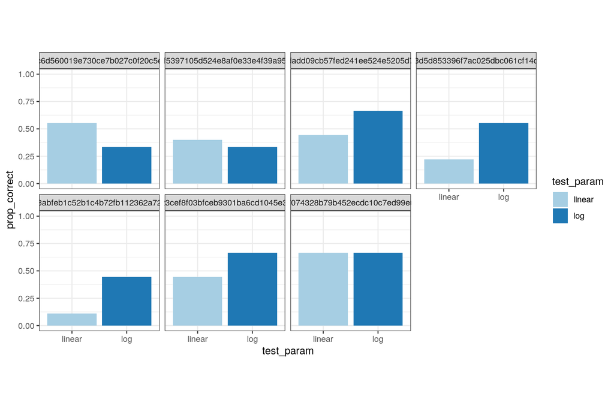